# R markdown, summary statistics and reproducible research (STAT5003)

Pengyi Yang

01 August, 2018

## Outlines

> - R data types.
> - R markdown.
> - Review basic statistical concept in data analysis.
> - Reproducible research - using R markdown to generate report.

## Introduction

### Learning objective

The aim here is to illustrate how to use R markdown to create data analysis report in a reproduciable manner. We will also review several summary statistics for exploratory data analysis and visualization.

## R data types

#### Atomic data types and operations

**Character**

```r
species <- "mouse"
```

**Integer**

```r
sampleSize <- 6
```

**Numeric**

```r
meanLifeSpan <- 2.05
```

**Factor**

```r
sex <- factor("male")
```

**Boolean**

```r
mammal <- TRUE
```

**Combine characters**

```r
strain <- "C57BL/6"
sampleDetail <- paste(species, strain)
sampleDetail
```

```
## [1] "mouse C57BL/6"
```

#### Primitive data types and operations

**Vectors**

```r
Groups <- c("treated", "control", "control", "control", "treated", "treated")
Groups
```

```
## [1] "treated" "control" "control" "control" "treated" "treated"
```

```r
lifeSpans <- c(2.1, 1.9, 1.7, 1.8, 2.3, 2.5)
lifeSpans
```

```
## [1] 2.1 1.9 1.7 1.8 2.3 2.5
```

```r
# Calculate mean life span of sample population
mean(lifeSpans)
```

```
## [1] 2.05
```

**List**

```r
# Split samples based on their groups
sampleByGroup <- split(lifeSpans, Groups)
sampleByGroup # sampleByGroup is a list
```

```
## $control
## [1] 1.9 1.7 1.8
##
## $treated
## [1] 2.1 2.3 2.5
```

```r
# access a single element in a list (get the mean of the second group)
sampleByGroup$treated # access by name using '$'
```

```
## [1] 2.1 2.3 2.5
```

```r
sampleByGroup[[2]] # access by index using '[[]]'
```

```
## [1] 2.1 2.3 2.5
```

```r
# calculate mean of samples in each group
means <- lapply(sampleByGroup, mean)
means
```

```
## $control
## [1] 1.8
##
## $treated
## [1] 2.3
```

```r
# calculate standard deviation of samples in each group
sds <- lapply(sampleByGroup, sd)
sds
```

```
## $control
## [1] 0.1
##
## $treated
## [1] 0.2
```

```r
sds[[2]] # access list by index
```

```
## [1] 0.2
```

**Matrix**

```r
# using cbind (column bind) to combine two vectors into a matrix
mat <- cbind(sampleByGroup$treated, sampleByGroup$control)
mat
```

```
##      [,1] [,2]
## [1,]  2.1  1.9
## [2,]  2.3  1.7
## [3,]  2.5  1.8
```

```r
colnames(mat) <- c("treated", "control") # assign column names
mat
```

```
##      treated control
## [1,]     2.1     1.9
## [2,]     2.3     1.7
## [3,]     2.5     1.8
```

```r
rownames(mat) <- paste("sample", 1:nrow(mat)) # assgin row names
mat
```

```
##          treated control
## sample 1     2.1     1.9
## sample 2     2.3     1.7
## sample 3     2.5     1.8
```

**Data frame**

```r
# create a data frame where life spans are stored in the first column and grouping information are stored in the second column
df <- data.frame(lifeSpans, Groups)
df
```

```
##   lifeSpans  Groups
## 1       2.1 treated
## 2       1.9 control
## 3       1.7 control
## 4       1.8 control
## 5       2.3 treated
## 6       2.5 treated
```

```r
# convert data frame into a list using function 'split'
sampleByGroup <- split(df[,1], df[,2])
sampleByGroup
```

```
## $control
## [1] 1.9 1.7 1.8
##
## $treated
## [1] 2.1 2.3 2.5
```

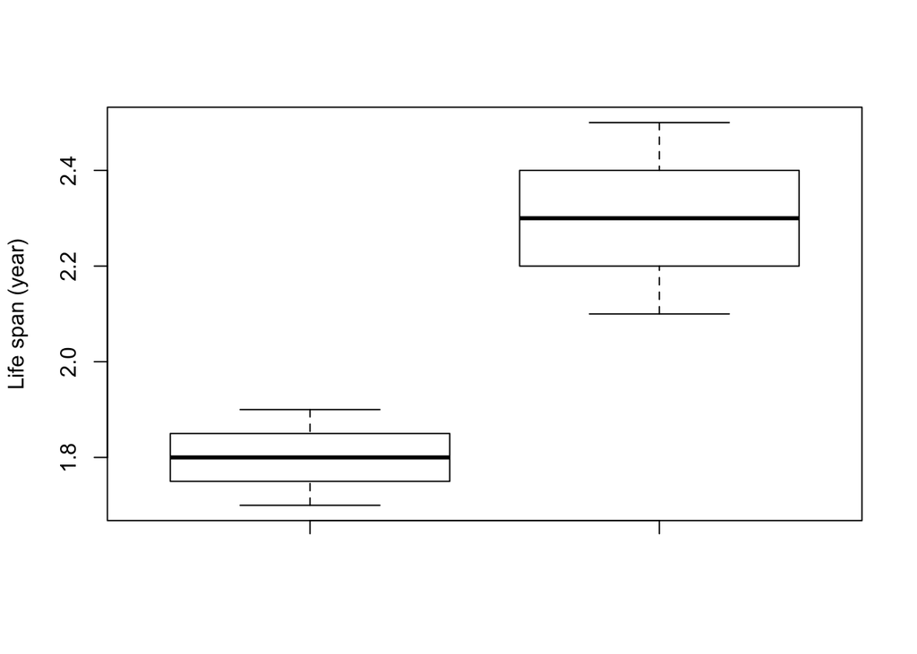

```r
# visualise the data using boxplot
boxplot(sampleByGroup$control, sampleByGroup$treated, ylab="Life span (year)")
```

```r
# perform a t-test with respect to life span between the two groups of samples
g1 <- sampleByGroup$treated
g2 <- sampleByGroup$control
t.test(g1, g2, alternative="greater")
```

```
##
##  Welch Two Sample t-test
##
## data:  g1 and g2
## t = 3.873, df = 2.9412, p-value = 0.01578
## alternative hypothesis: true difference in means is greater than 0
## 95 percent confidence interval:
##  0.1936888       Inf
## sample estimates:
## mean of x mean of y
##       2.3       1.8
```

## Libraries to load

```r
library(reshape2)
library(ggplot2)
library(devtools)
#install_github("vqv/ggbiplot") # run this line if you haven't installed ggbiplot
library(ggbiplot)
library(gplots)
library(gridExtra)
library(scales)
library(limma)
```

### Iris dataset description

This famous (Fisher’s or Anderson’s) iris data set gives the measurements in centimeters of the variables sepal length and width and petal length and width, respectively, for 50 flowers from each of 3 species of iris. The species are Iris setosa, versicolor, and virginica.

References Becker, R. A., Chambers, J. M. and Wilks, A. R. (1988) The New S Language. Wadsworth & Brooks/Cole. (has iris3 as iris.)

## Data exploration on iris dataset

```r
# obtain and summarize phenodata
dim(iris)
```

```
## [1] 150   5
```

```r
head(iris)
```

```
##   Sepal.Length Sepal.Width Petal.Length Petal.Width Species
## 1          5.1         3.5          1.4         0.2  setosa
## 2          4.9         3.0          1.4         0.2  setosa
## 3          4.7         3.2          1.3         0.2  setosa
## 4          4.6         3.1          1.5         0.2  setosa
## 5          5.0         3.6          1.4         0.2  setosa
## 6          5.4         3.9          1.7         0.4  setosa
```

```r
table(iris$Species)
```

```
##
##     setosa versicolor  virginica
##         50         50         50
```

```r
class(iris)
```

```
## [1] "data.frame"
```

Let us first extract data from a single variable “Sepal Length”. We will use this to review basic R commands for numeric and graphical summaries.

### Numerical summaries for univariate data

```r
sepalLength <- iris$Sepal.Length
mean(sepalLength) ## Calculating the mean
```

```
## [1] 5.843333
```

```r
median(sepalLength) ## Calculating the median
```

```
## [1] 5.8
```

```r
quantile(sepalLength) ## Calculating quantiles
```

```
##   0%  25%  50%  75% 100%
##  4.3  5.1  5.8  6.4  7.9
```

```r
IQR(sepalLength) ##  Calculating the Interquartile range
```

```
## [1] 1.3
```

```r
sd(sepalLength) ## Calculating standard deviation
```

```
## [1] 0.8280661
```

```r
var(sepalLength) ## Calculating variance
```

```
## [1] 0.6856935
```

```r
range(sepalLength) ## Calculating the range
```

```
## [1] 4.3 7.9
```

```r
max(sepalLength) ## Calculating maximum value
```

```
## [1] 7.9
```

```r
min(sepalLength) ## Calculating minimum value
```

```
## [1] 4.3
```

```r
summary(sepalLength) ## Numerical summary of "sepalLength"
```

```
##    Min. 1st Qu.  Median    Mean 3rd Qu.    Max.
##   4.300   5.100   5.800   5.843   6.400   7.900
```

### Graphical summaries for univariate data

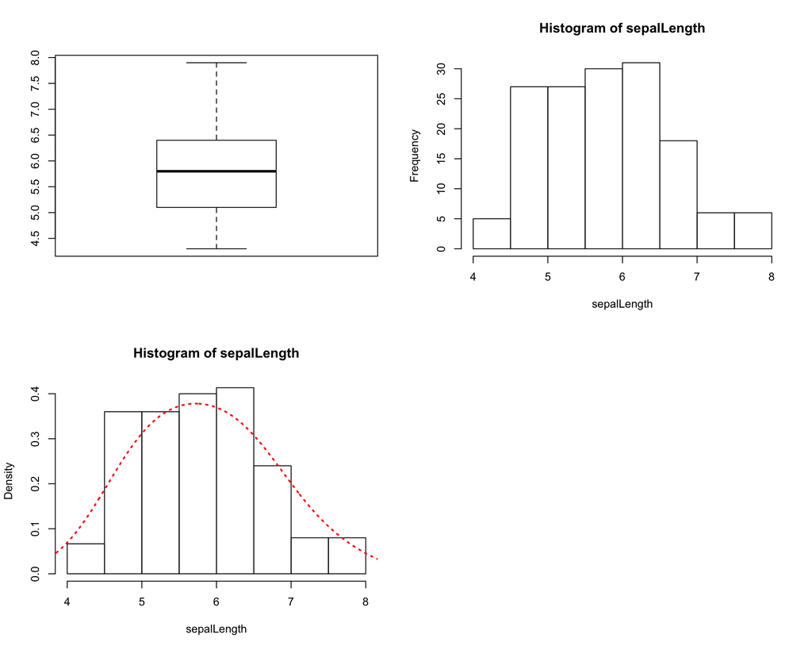

```r
par(mfrow=c(2, 2))
boxplot(sepalLength)
hist(sepalLength, breaks=10) ## Shows the distribution of expression of different genes by frequency
hist(sepalLength, breaks=10, probability = TRUE) ## Shows the distribution of expression of different genes by probability (density)
lines(density(sepalLength, adjust=2), lty="dotted", col="red", lwd=2) ## Estimate the density of sepalLength
```

### Numeric and graphical summary for bivariate data

Scatterplots provide insight into relationships between variables, for example, sugars and calories or fat and calories, etc. You can also calculate correlation between any pairs of variables (as shown below).

```r
petalLength <- iris$Petal.Length
cor(sepalLength, petalLength) # correlation between sepal length and Petal length
```

```
## [1] 0.8717538
```

```r
lm(sepalLength~petalLength) # fitting a linear model to the two variables
```

```
##
## Call:
## lm(formula = sepalLength ~ petalLength)
##
## Coefficients:
## (Intercept)  petalLength
##      4.3066       0.4089
```

```r
coef(lm(sepalLength ~ petalLength)) # extract coefficients
```

```
## (Intercept) petalLength
##   4.3066034   0.4089223
```

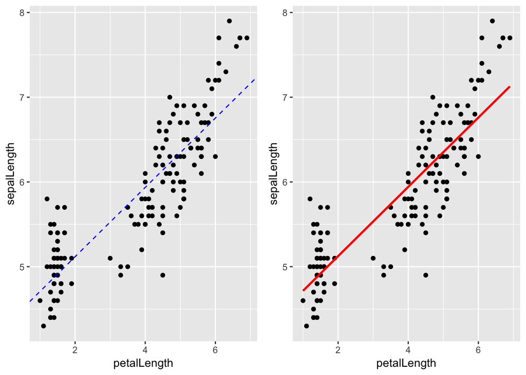

```r
plot1 <- qplot(petalLength, sepalLength) + geom_abline(intercept = 4.3, slope = 0.409, col="blue", linetype = 2) # plot one variable vs another; correlation plot; add a regression line using intercept and slope obtained from the coef() function
plot2 <- qplot(petalLength, sepalLength) + geom_smooth(method = "lm", se = FALSE, col="red") ## Add a regression line using geom_smooth function
grid.arrange(plot1, plot2, ncol=2) # arrange plots using grid
```

### Species based analysis (split data, analyse and compare three species)

In this section, we review how to parse data and visualise them based on factors (species) of interest

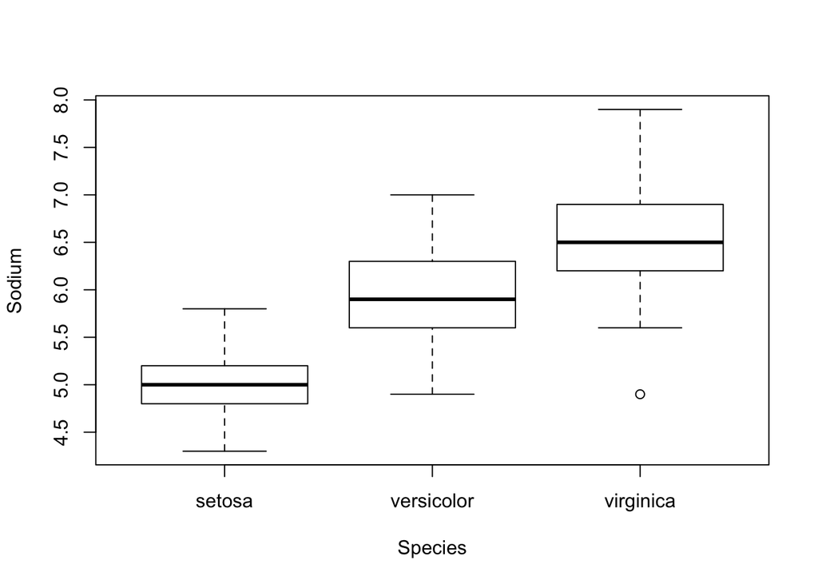

```r
boxplot(split(sepalLength, iris$Species), ylab="Sodium", xlab="Species") # using base plot system. We are splitting the "sepal length" by using "species" as a factor here.
```

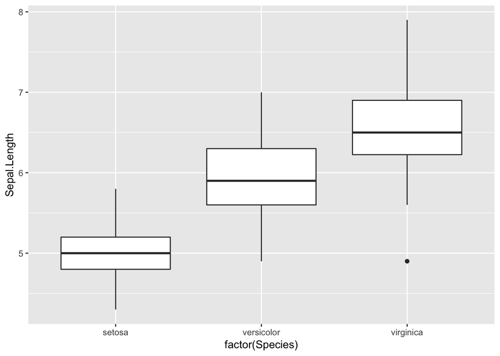

```r
ggplot(iris, aes(factor(Species), Sepal.Length)) + geom_boxplot() # using ggplot system. Function "aes" are used to split the data
```

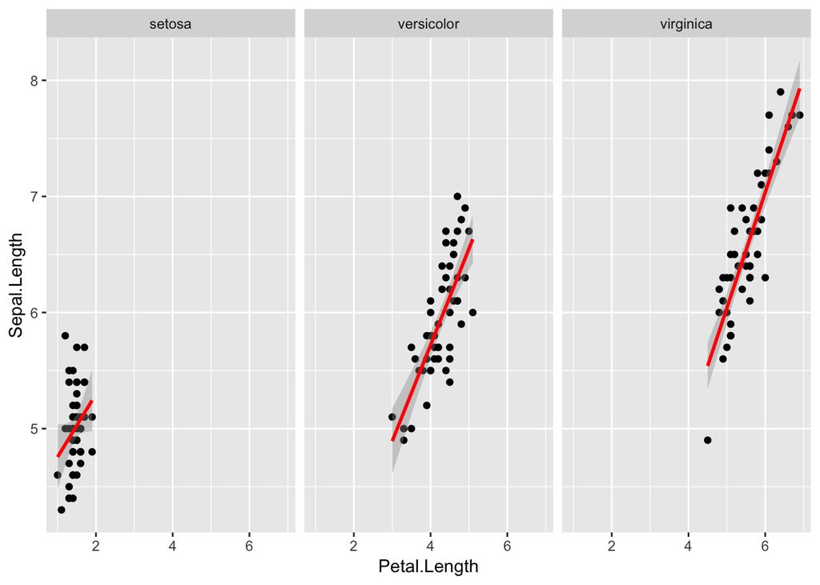

```r
ggplot(iris, aes(y=Sepal.Length, x=Petal.Length)) + geom_point() + facet_grid(. ~ Species) + geom_smooth(method = "lm", se = TRUE, col="red")
```

## Data analysis on Leukemia gene expression dataset

### Leukemia dataset description

ExpressionSet containing gene expresion data from 60 bone marrow samples of patients with one of the four main types of leukemia (ALL, AML, CLL, CML) or no-leukemia controls.

Platform: Affymetrix Human Genome U133 Plus 2.0

Annotation: genemapperhgu133plus2 (CDF from GATExplorer)

Mapping: Gene Ensembl ID (20172 features)

Tissue: Bone Marrow

Cell type: Mononuclear cells isolated by Ficoll density centrifugation

Disease type:  
1. Acute Lymphoblastic Leukemia (ALL). Subtype: c-ALL / pre-B-ALL without t(9;22)  
2. Acute Myeloid Leukemia (AML). Subtype: Normal karyotype  
3. Chronic Lymphocytic Leukemia (CLL)  
4. Chronic Myeloid Leukemia (CML)  
5. Non-leukemia and healthy bone marrow (NoL)

All samples were obtained from untreated patients at the time of diagnosis. Preprocessing: The microarrays were normalized with RMA using a redefined probe mapping from Affymetrix probesets to Ensembl genes (Ensembl IDs ENSG). This alternative Chip Definition File (CDF) with complete unambiguous mapping of microarray probes to genes (GeneMapper) is available at GATExplorer (http://bioinfow.dep.usal.es/xgate/mapping/mapping.php) (Risueno et al. 2010).

### Aims

#### obtain and load data

```r
# download data from bioconductor
source("https://bioconductor.org/biocLite.R")
biocLite("leukemiasEset")
```

```r
# load data
library(leukemiasEset)
data(leukemiasEset)

# extract expression matrix from the "ExpressionSet object"
leukemia.mat <- exprs(leukemiasEset)
class(leukemia.mat)
```

```
## [1] "matrix"
```

```r
# obtain and summarize phenodata
phenodata <- pData(leukemiasEset)
head(phenodata)
```

```
##               Project     Tissue LeukemiaType         LeukemiaTypeFullName
## GSM330151.CEL   Mile1 BoneMarrow          ALL Acute Lymphoblastic Leukemia
## GSM330153.CEL   Mile1 BoneMarrow          ALL Acute Lymphoblastic Leukemia
## GSM330154.CEL   Mile1 BoneMarrow          ALL Acute Lymphoblastic Leukemia
## GSM330157.CEL   Mile1 BoneMarrow          ALL Acute Lymphoblastic Leukemia
## GSM330171.CEL   Mile1 BoneMarrow          ALL Acute Lymphoblastic Leukemia
## GSM330174.CEL   Mile1 BoneMarrow          ALL Acute Lymphoblastic Leukemia
##                                       Subtype
## GSM330151.CEL c_ALL/Pre_B_ALL without t(9 22)
## GSM330153.CEL c_ALL/Pre_B_ALL without t(9 22)
## GSM330154.CEL c_ALL/Pre_B_ALL without t(9 22)
## GSM330157.CEL c_ALL/Pre_B_ALL without t(9 22)
## GSM330171.CEL c_ALL/Pre_B_ALL without t(9 22)
## GSM330174.CEL c_ALL/Pre_B_ALL without t(9 22)
```

```r
table(phenodata[,"LeukemiaType"])
```

```
##
## ALL AML CLL CML NoL
##  12  12  12  12  12
```

#### Summarise data

```r
dim(leukemia.mat)
```

```
## [1] 20172    60
```

```r
head(leukemia.mat)
```

```
##                 GSM330151.CEL GSM330153.CEL GSM330154.CEL GSM330157.CEL
## ENSG00000000003      3.386743      3.687029      3.360517      3.459388
## ENSG00000000005      3.539030      3.836208      3.246327      3.063286
## ENSG00000000419      9.822758      7.969170      9.457491      9.591018
## ENSG00000000457      4.747283      4.866344      4.981642      5.982854
## ENSG00000000460      3.307188      4.046402      5.529369      4.619444
## ENSG00000000938      8.230721      7.945818      6.411830      6.882017
##                 GSM330171.CEL GSM330174.CEL GSM330178.CEL GSM330182.CEL
## ENSG00000000003      3.598589      3.266450      3.625621      3.328542
## ENSG00000000005      3.307543      2.898742      3.376554      3.099215
## ENSG00000000419      9.863687      9.357091      8.456825      9.391422
## ENSG00000000457      5.779449      6.251031      5.406869      6.282383
## ENSG00000000460      3.352696      4.385865      5.333182      3.833876
## ENSG00000000938      7.202573      5.975625      8.771939      6.941649
##                 GSM330185.CEL GSM330186.CEL GSM330195.CEL GSM330201.CEL
## ENSG00000000003      3.366848      3.594673      3.230963      3.400032
## ENSG00000000005      3.105748      3.267860      3.173425      3.127229
## ENSG00000000419      8.810066      9.543697     10.146661      9.665457
## ENSG00000000457      5.419578      5.045518      6.621514      5.516059
## ENSG00000000460      3.957826      4.382035      4.518303      3.609921
## ENSG00000000938      7.744927      4.643585      5.565929      5.504311
##                 GSM330532.CEL GSM330546.CEL GSM330559.CEL GSM330566.CEL
## ENSG00000000003      3.555251      3.445626      3.307000      3.704270
## ENSG00000000005      3.407366      3.285541      3.304056      3.766061
## ENSG00000000419      8.890326      9.227033      9.254888      7.642620
## ENSG00000000457      5.781813      6.918744      5.951737      6.442780
## ENSG00000000460      4.139324      3.930888      3.867513      3.639747
## ENSG00000000938      8.908160      8.354787     11.254085      7.896291
##                 GSM330571.CEL GSM330574.CEL GSM330580.CEL GSM330584.CEL
## ENSG00000000003      3.795123      3.408715      3.936968      3.539508
## ENSG00000000005      3.393322      3.192542      3.485599      3.207444
## ENSG00000000419      9.894416     10.069000      9.909859      9.829838
## ENSG00000000457      5.448561      5.415535      6.159061      6.430894
## ENSG00000000460      3.533347      3.290300      3.505252      5.059260
## ENSG00000000938     10.317744      5.724016      8.211415      7.892952
##                 GSM330593.CEL GSM330603.CEL GSM330611.CEL GSM330612.CEL
## ENSG00000000003      3.877059      3.437316      3.647472      3.497533
## ENSG00000000005      3.365767      3.135391      3.250473      3.379662
## ENSG00000000419      9.745587      9.278768      9.675329      9.626516
## ENSG00000000457      4.876383      6.234634      5.284237      6.646543
```

[output cut: 50 more lines]

```
## ENSG00000000938     10.337569     11.139956     11.057364     10.434833
##                 GSM331668.CEL GSM331670.CEL GSM331671.CEL GSM331672.CEL
## ENSG00000000003      3.761320      3.400238      3.998795      3.527267
## ENSG00000000005      3.448587      3.368988      3.364461      3.085926
## ENSG00000000419      9.175445      9.567669      9.483960      9.379586
## ENSG00000000457      4.290208      5.656464      5.489518      6.417579
## ENSG00000000460      3.987372      4.125539      4.027215      4.304499
## ENSG00000000938     10.326610     10.900301     11.203853     11.570332
##                 GSM331673.CEL GSM331674.CEL GSM331675.CEL GSM331677.CEL
## ENSG00000000003      3.558177      3.534243      3.563473      3.628648
## ENSG00000000005      3.462798      3.336127      3.128173      3.146411
## ENSG00000000419      9.354106      9.179998      9.572337      9.405463
## ENSG00000000457      5.411642      5.781067      6.177777      5.803727
## ENSG00000000460      4.718666      4.038663      4.145901      5.723994
## ENSG00000000938     11.289805     11.465760     10.930981     10.980726
```

```r
colnames(leukemia.mat)
```

```
##  [1] "GSM330151.CEL" "GSM330153.CEL" "GSM330154.CEL" "GSM330157.CEL"
##  [5] "GSM330171.CEL" "GSM330174.CEL" "GSM330178.CEL" "GSM330182.CEL"
##  [9] "GSM330185.CEL" "GSM330186.CEL" "GSM330195.CEL" "GSM330201.CEL"
## [13] "GSM330532.CEL" "GSM330546.CEL" "GSM330559.CEL" "GSM330566.CEL"
## [17] "GSM330571.CEL" "GSM330574.CEL" "GSM330580.CEL" "GSM330584.CEL"
## [21] "GSM330593.CEL" "GSM330603.CEL" "GSM330611.CEL" "GSM330612.CEL"
## [25] "GSM330933.CEL" "GSM330934.CEL" "GSM330969.CEL" "GSM330979.CEL"
## [29] "GSM330980.CEL" "GSM330982.CEL" "GSM330987.CEL" "GSM330999.CEL"
## [33] "GSM331004.CEL" "GSM331009.CEL" "GSM331037.CEL" "GSM331048.CEL"
## [37] "GSM331377.CEL" "GSM331378.CEL" "GSM331381.CEL" "GSM331382.CEL"
## [41] "GSM331383.CEL" "GSM331386.CEL" "GSM331387.CEL" "GSM331388.CEL"
## [45] "GSM331389.CEL" "GSM331390.CEL" "GSM331392.CEL" "GSM331393.CEL"
## [49] "GSM331660.CEL" "GSM331661.CEL" "GSM331663.CEL" "GSM331666.CEL"
## [53] "GSM331668.CEL" "GSM331670.CEL" "GSM331671.CEL" "GSM331672.CEL"
## [57] "GSM331673.CEL" "GSM331674.CEL" "GSM331675.CEL" "GSM331677.CEL"
```

## Hypothesis testing:

### ANOVA for selecting differentially expressed genes

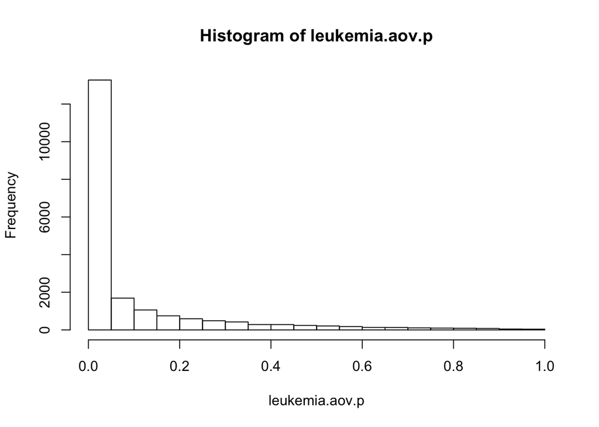

```r
# extract phenotype data
f <- phenodata[colnames(leukemia.mat), 3]
# apply ANOVA to each row (aka each gene) of the leukemia matrix
leukemia.aov.p <- apply(leukemia.mat, 1, function(x){
    summary(aov(as.numeric(x) ~ f))[[1]][["Pr(>F)"]][1]
})
hist(leukemia.aov.p)
```

### Limma’s moderated t-test and f-test

```r
# create the design matrix
f = phenodata[colnames(leukemia.mat), 3]
design = model.matrix(~ f - 1)
colnames(design) <- c("ALL", "AML", "CLL", "CML", "NoL")
design
```

```
##    ALL AML CLL CML NoL
## 1    1   0   0   0   0
## 2    1   0   0   0   0
## 3    1   0   0   0   0
## 4    1   0   0   0   0
## 5    1   0   0   0   0
## 6    1   0   0   0   0
## 7    1   0   0   0   0
## 8    1   0   0   0   0
## 9    1   0   0   0   0
## 10   1   0   0   0   0
## 11   1   0   0   0   0
## 12   1   0   0   0   0
## 13   0   1   0   0   0
## 14   0   1   0   0   0
```

[output cut: 51 more lines]

```r
fit <- lmFit(leukemia.mat , design) # fitting data to a linear model
contrast.matrix <- makeContrasts(ALL-NoL, AML-NoL, CLL-NoL, CML-NoL, levels=design)  # defining group comparisons
fit2 <- contrasts.fit(fit, contrast.matrix) # convert the coefficients of the design matrix into these 4 contrasts which are to be tested equal to zero
fit2 <- eBayes(fit2) # With a series of related parameter estimates & standard errors, eBayes computes moderated t-statistics of differential expression by empirical Bayes shrinkage of the standard errors towards a common value.
topTable(fit2, coef=1, number=Inf)[1:10,] # Extract test results based on moderated t-test with respect to ALL
```

```
##                     logFC  AveExpr         t      P.Value    adj.P.Val
## ENSG00000102935  4.994174 4.552422  19.38710 6.562099e-27 1.323707e-22
## ENSG00000100099  2.473308 6.933710  17.37748 1.443735e-24 1.456151e-20
## ENSG00000178217  2.420520 4.020113  17.02465 3.891526e-24 2.616662e-20
## ENSG00000159339 -4.261225 6.669315 -14.89040 2.128662e-21 1.073484e-17
## ENSG00000134369  2.862998 5.233725  14.69436 3.904204e-21 1.575112e-17
## ENSG00000106665  3.341961 5.672217  14.61896 4.936336e-21 1.659596e-17
## ENSG00000170482  2.686008 4.530692  14.39268 1.002231e-20 2.888143e-17
## ENSG00000164330  4.912293 5.289716  14.24431 1.600129e-20 4.034724e-17
## ENSG00000130635  3.656821 5.026585  14.05077 2.958078e-20 6.630038e-17
## ENSG00000145569 -2.845963 5.870194 -13.77699 7.112241e-20 1.434681e-16
##                        B
## ENSG00000102935 50.27408
## ENSG00000100099 45.17930
## ENSG00000178217 44.23617
## ENSG00000159339 38.19906
## ENSG00000134369 37.61488
## ENSG00000106665 37.38882
## ENSG00000170482 36.70585
## ENSG00000164330 36.25428
## ENSG00000130635 35.66076
## ENSG00000145569 34.81252
```

```r
limma.f.p <- fit2$F.p.value # Extract the p-value from the moderated f-test model
names(limma.f.p) <- rownames(fit2)
```

### compare consensus of the two approaches

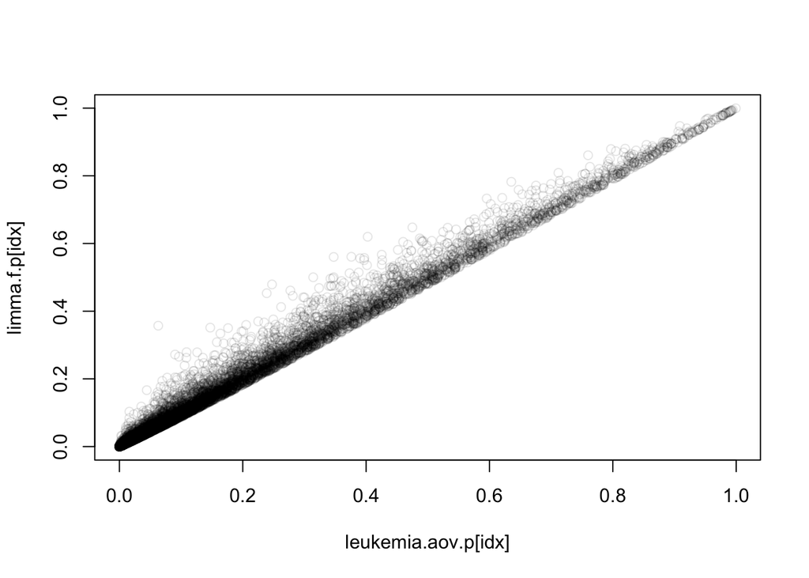

```r
idx <- names(leukemia.aov.p)
plot(leukemia.aov.p[idx], limma.f.p[idx], col = alpha("black", 0.1))
```

### Note about this document

[session information not shown]